# Using pretrained models

Based on https://blog.keras.io/building-powerful-image-classification-models-using-very-little-data.html and the really helpful courses of http://www.fast.ai/ (dogs_cats_redux.ipynb).

## Action Plan

1. Perparing Data
2. Finetune and Train model
3. Generate predictions
4. Validate predictions
5. Submit predictions to Kaggle
6. Under/Overfitting

Pretrained Models for TF:

https://github.com/fchollet/deep-learning-models

https://github.com/fchollet/deep-learning-models/releases

## General ^

```python
import random, time
import sys
stdout = sys.stdout
#sys.stdout = open('keras_output.txt', 'a+')
#sys.stdout = stdout

%matplotlib inline

import utils
from utils import *
import importlib
importlib.reload(utils)

import twBase
importlib.reload(twBase)

from keras.preprocessing import image

from IPython.core.debugger import Tracer
#Tracer()()

#Allow relative imports to directories above cwd/
sys.path.insert(1, os.path.join(sys.path[0], '..'))

%matplotlib inline

current_dir = os.getcwd()
```

```
<module 'utils' from '/Users/q187392/dev/py/module/twBase/utils.py'>
```

```
<module 'twBase' from '/Users/q187392/dev/py/module/twBase/twBase.py'>
```

## Preparing Data ^

To start you will need to download and unzip the competition data from Kaggle and ensure your directory structure looks like this

```
└── data
    ├── results
    ├── sample
    │   ├── results
    │   ├── test
    │   ├── train
    │   │   ├── cats
    │   │   └── dogs
    │   └── valid
    │       ├── cats
    │       └── dogs
    ├── test
    │   └── unknown
    ├── train
    │   ├── cats
    │   └── dogs
    └── valid
        ├── cats
        └── dogs
```

Download data into `./data` and unzip it. https://www.kaggle.com/c/dogs-vs-cats-redux-kernels-edition/data

### Create validation set and sample

```python
DATA_HOME_DIR = '/Users/q187392/kg/cac/data'
```

```python
#Create directories
%cd $DATA_HOME_DIR

%mkdir valid
%mkdir results
%mkdir -p sample/train
%mkdir -p sample/test
%mkdir -p sample/valid
%mkdir -p sample/results
%mkdir -p test/unknown
%mkdir -p sample/test/unknown
```

```
/Users/q187392/kg/cac/data
mkdir: cannot create directory ‘valid’: File exists
mkdir: cannot create directory ‘results’: File exists
```

```python
%cd $DATA_HOME_DIR/train

# move data as validation set
g = glob('dog.*.jpg')
shuf = np.random.permutation(g)
for i in range(1000): os.rename(shuf[i], DATA_HOME_DIR+'/valid/' + shuf[i])

g = glob('cat.*.jpg')
shuf = np.random.permutation(g)
for i in range(1000): os.rename(shuf[i], DATA_HOME_DIR+'/valid/' + shuf[i])
```

```
'/Users/q187392/kg/cac/data'
```

```
/Users/q187392/kg/cac/data/train
```

```python
%cd $DATA_HOME_DIR/train

# create sample set
g = glob('dog.*.jpg')
shuf = np.random.permutation(g)
for i in range(100): _ = copyfile(shuf[i], DATA_HOME_DIR+'/sample/train/' + shuf[i])

g = glob('cat.*.jpg')
shuf = np.random.permutation(g)
for i in range(100): _ = copyfile(shuf[i], DATA_HOME_DIR+'/sample/train/' + shuf[i])
```

```python
%cd $DATA_HOME_DIR/valid

g = glob('dog.*.jpg')
shuf = np.random.permutation(g)
for i in range(20): _ = copyfile(shuf[i], DATA_HOME_DIR+'/sample/valid/' + shuf[i])
g = glob('cat.*.jpg')
shuf = np.random.permutation(g)
for i in range(20): _ = copyfile(shuf[i], DATA_HOME_DIR+'/sample/valid/' + shuf[i])

%cd $DATA_HOME_DIR
```

```
/Users/q187392/kg/cac/data/valid
/Users/q187392/kg/cac/data
```

```python
%cd $DATA_HOME_DIR/test/unknown

g = glob('*.jpg')
shuf = np.random.permutation(g)
for i in range(20): _ = copyfile(shuf[i], DATA_HOME_DIR+'/sample/test/unknown/' + shuf[i])

%cd $DATA_HOME_DIR
```

```
/Users/q187392/kg/cac/data/test/unknown
/Users/q187392/kg/cac/data
```

### Rearrange image files into their respective directories

```python
#Divide cat/dog images into separate directories

%cd $DATA_HOME_DIR/sample/train
%mkdir cats
%mkdir dogs
%mv cat.*.jpg cats/
%mv dog.*.jpg dogs/

%cd $DATA_HOME_DIR/sample/valid
%mkdir cats
%mkdir dogs
%mv cat.*.jpg cats/
%mv dog.*.jpg dogs/

%cd $DATA_HOME_DIR/valid
%mkdir cats
%mkdir dogs
%mv cat.*.jpg cats/
%mv dog.*.jpg dogs/

%cd $DATA_HOME_DIR/train
%mkdir cats
%mkdir dogs
%mv cat.*.jpg cats/
%mv dog.*.jpg dogs/
```

```
/Users/q187392/kg/cac/data/sample/train
/Users/q187392/kg/cac/data/sample/valid
/Users/q187392/kg/cac/data/valid
/Users/q187392/kg/cac/data/train
```

```python
# Create single 'unknown' class for test set
%cd $DATA_HOME_DIR/test
%mv *.jpg unknown/
```

```
/Users/q187392/kg/cac/data/test
```

### Get sample picture

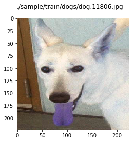

```python
import cv2
def get_randomImg(path='./sample/train', target_size=(224, 224)):
    random.seed = time.time
    classtype = random.choice(['cats', 'dogs'])
    if not path.endswith('/'):
        path += '/'

    img_path = random.choice(glob(path+'{}/*.jpg'.format(classtype)))

    img = image.load_img(img_path, target_size=target_size)
    testImg = image.img_to_array(img)
    testImg = np.expand_dims(testImg, axis=0)
    testImg = preprocess_input(testImg)

    plt.imshow(image.array_to_img(testImg[0]))
    plt.suptitle(img_path)
    plt.show()
    return testImg


testImg = get_randomImg('./sample/train')
```

### Data Generator

`flow_from_directory` returns an iterator which takes the path to a directory, and generates batches of augmented/normalized data. It yields batches indefinitely, in an infinite loop.

```python
%cd $DATA_HOME_DIR

size = 224
batch_size = 32

# this is the augmentation configuration we will use for training
augment_datagen = ImageDataGenerator(
        rescale=1./255,
        shear_range=0.2,
        zoom_range=0.2,
        horizontal_flip=True)

# this is the augmentation configuration we will use for testing: only rescaling
pure_datagen = ImageDataGenerator(rescale=1./255)

# this is a generator that will read pictures found in
# subfolers of 'data/train', and indefinitely generate
# batches of augmented image data
train_generator = augment_datagen.flow_from_directory(
        'sample/train',  # this is the target directory
        save_to_dir=None,
        target_size=(size, size),  # all images will be resized to 150x150
        batch_size=batch_size,
        #class_mode='binary',  # since we use binary_crossentropy loss, we need binary labels
        class_mode=None,  # this means our generator will only yield batches of data, no labels
        shuffle=False  # our data will be in order, so all first 1000 images will be cats, then 1000 dogs
)

# this is a similar generator, for validation data
validation_generator = pure_datagen.flow_from_directory(
        'sample/valid',
        save_to_dir=None,
        target_size=(size, size),
        batch_size=batch_size,
        #class_mode='binary',
        class_mode=None,
        shuffle=False  # our data will be in order, so all first 1000 images will be cats, then 1000 dogs
)
```

```
/Users/q187392/kg/cac/data
Found 200 images belonging to 2 classes.
Found 40 images belonging to 2 classes.
```

## Model, Training and Finetuning ^

### VGG16 Image Net Classification ^

```python
from keras.applications.vgg16 import preprocess_input, decode_predictions
full_model = VGG16(weights='imagenet', include_top=True)
preds = full_model.predict(testImg)
# decode the results into a list of tuples (class, description, probability)
# (one such list for each sample in the batch)
print('Predicted:', decode_predictions(preds, top=3)[0])
```

```
Predicted: [('n02124075', 'Egyptian_cat', 0.41724393), ('n02123045', 'tabby', 0.27504596), ('n02123159', 'tiger_cat', 0.22018097)]
```

### VGG16 model without top dense layers (Feature extraction) ^

We extract the features after the convolutional blocks and try put a bespoke fully connected dense layer on top. Thus we need to stream all pictures without labels through the convolutional layers and predict the features. Data augmentation cannot be done with this approach.

#### Create the Base Model

```python
# create vgg16 feature mode (without dense layers)
from keras.applications.vgg16 import VGG16
from keras.applications.vgg16 import preprocess_input
import numpy as np

input_shape = (size, size, 3)
img = Input(shape=input_shape, name='image_input')
base_model = VGG16(weights='imagenet', include_top=False, input_tensor=img)
```

```python
# only necessary for trainig
#base_model.compile(optimizer='adam', loss='binary_crossentropy')
#base_model.summary()
```

#### Create the features

```python
# extract features for the first 32 pics
xxx = base_model.predict_generator(train_generator, 32)
xxx.shape
```

```
(32, 7, 7, 512)
```

```python
# the predict_generator method returns the output of a model, given a generator that yields batches of numpy data
bottleneck_features_train = base_model.predict_generator(train_generator, 200)
np.save('bottleneck_features_train.npy', bottleneck_features_train)
```

```python
bottleneck_features_validation = base_model.predict_generator(validation_generator, 40)
np.save('bottleneck_features_validation.npy', bottleneck_features_validation)
```

```python
train_data = np.load('bottleneck_features_train.npy')
# the features were saved in order, so recreating the labels is easy
train_labels = np.array([0] * 100 + [1] * 100)

validation_data = np.load('bottleneck_features_validation.npy')
validation_labels = np.array([0] * 20 + [1] * 20)

train_data.shape, validation_data.shape
```

```
((200, 7, 7, 512), (40, 7, 7, 512))
```

#### Create and train Dense model

Dense fully connected model will be trained with saved features as input.

```python
dense_model = Sequential()
dense_model.add(Flatten(input_shape=train_data.shape[1:]))
dense_model.add(Dense(256, activation='relu'))
dense_model.add(Dropout(0.5))
dense_model.add(Dense(1, activation='sigmoid'))

dense_model.compile(optimizer='rmsprop',
              loss='binary_crossentropy',
              metrics=['accuracy'])
```

```python
dense_model.fit(train_data, train_labels,
          nb_epoch=10, batch_size=batch_size,
          validation_data=(validation_data, validation_labels))

dense_model.save_weights('bottleneck_fc_model.h5')
```

```
Train on 200 samples, validate on 40 samples
```

```
<keras.callbacks.History at 0x41f6bb5f8>
```

```
array([[ 1.]], dtype=float32)
```

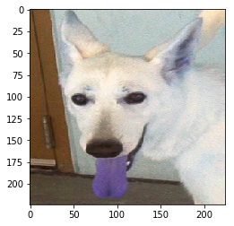

```python
# make prediction
plt.imshow(image.array_to_img(testImg[0]))
dense_model.predict(base_model.predict(testImg))
```

### Finetuning of VGG16 with custom top dense layer ^

We train now the full model, so data augmentation is possible.

Things to take into account (https://blog.keras.io/building-powerful-image-classification-models-using-very-little-data.html):

- in order to perform fine-tuning, all layers should start with properly trained weights: for instance you should not slap a randomly initialized fully-connected network on top of a pre-trained convolutional base. This is because the large gradient updates triggered by the randomly initialized weights would wreck the learned weights in the convolutional base. In our case this is why we first train the top-level classifier, and only then start fine-tuning convolutional weights alongside it.
- we choose to only fine-tune the last convolutional block rather than the entire network in order to prevent overfitting, since the entire network would have a very large entropic capacity and thus a strong tendency to overfit. The features learned by low-level convolutional blocks are more general, less abstract than those found higher-up, so it is sensible to keep the first few blocks fixed (more general features) and only fine-tune the last one (more specialized features).
- fine-tuning should be done with a very slow learning rate, and typically with the SGD optimizer rather than an adaptative learning rate optimizer such as RMSProp. This is to make sure that the magnitude of the updates stays very small, so as not to wreck the previously learned features.

#### Prepare data feeding

```python
# now we need the batches WITH labels
%cd $DATA_HOME_DIR

train_generator = augment_datagen.flow_from_directory(
        'sample/train',
        save_to_dir=None,
        target_size=(size, size),
        batch_size=batch_size,
        class_mode='binary',  # since we use binary_crossentropy loss, we need binary labels
        shuffle=False  # our data will be in order, so all first 1000 images will be cats, then 1000 dogs
)

# this is a similar generator, for validation data
validation_generator = pure_datagen.flow_from_directory(
        'sample/valid',
        save_to_dir=None,
        target_size=(size, size),
        batch_size=batch_size,
        class_mode='binary',
        shuffle=False  # our data will be in order, so all first 1000 images will be cats, then 1000 dogs
)
```

```
/Users/q187392/kg/cac/data
Found 200 images belonging to 2 classes.
Found 40 images belonging to 2 classes.
```

#### Recreate the pretrained dense model

```python
# create top_model to put on top of vgg16
input = Input(shape=base_model.output_shape[1:])
x = Flatten()(input)
x = Dense(256, activation='relu')(x)
x = Dropout(0.5)(x)
x = Dense(1, activation='sigmoid')(x)
top_model = Model(input=input, output=x, name='top_model')
top_model_weights_path = 'bottleneck_fc_model.h5'
top_model.load_weights(top_model_weights_path)
top_model.summary()
```

```
____________________________________________________________________________________________________
Layer (type)                     Output Shape          Param #     Connected to
====================================================================================================
input_61 (InputLayer)            (None, 7, 7, 512)     0
____________________________________________________________________________________________________
flatten_52 (Flatten)             (None, 25088)         0           input_61[0][0]
____________________________________________________________________________________________________
dense_92 (Dense)                 (None, 256)           6422784     flatten_52[0][0]
____________________________________________________________________________________________________
dropout_46 (Dropout)             (None, 256)           0           dense_92[0][0]
____________________________________________________________________________________________________
dense_93 (Dense)                 (None, 1)             257         dropout_46[0][0]
====================================================================================================
Total params: 6,423,041
Trainable params: 6,423,041
Non-trainable params: 0
____________________________________________________________________________________________________
```

#### Create and train the full model based onVgg16 and the bespoke pretrained dense model

```python
from keras.optimizers import SGD

#x = base_model.output  # shows all vgg16 layers in model.summary
x = base_model(img)  # creates vgg16 layer im model.summary
x = top_model(x)

# this is the model we will train
#model = Model(input=base_model.input, output=x)
model = Model(input=img, output=x)
model.summary()

# first: train only the top layers (which were randomly initialized)
# i.e. freeze all convolutional layers
for layer in base_model.layers:
    log.info("Freeze layer in base_model", layer=layer.name)
    layer.trainable = False

for layer in top_model.layers:
    log.info("Unfreeze layer in top_model", layer=layer.name)
    layer.trainable = True

# compile the model (should be done *after* setting layers to non-trainable)
model.compile(loss='binary_crossentropy',
              optimizer=SGD(lr=1e-4, momentum=0.9),
              metrics=['accuracy'])
```

```
____________________________________________________________________________________________________
Layer (type)                     Output Shape          Param #     Connected to
====================================================================================================
image_input (InputLayer)         (None, 224, 224, 3)   0
____________________________________________________________________________________________________
vgg16 (Model)                    (None, 7, 7, 512)     14714688    image_input[0][0]
____________________________________________________________________________________________________
top_model (Model)                (None, 1)             6423041     vgg16[1][0]
====================================================================================================
Total params: 21,137,729
Trainable params: 21,137,729
Non-trainable params: 0
____________________________________________________________________________________________________
layer='image_input' event='Freeze layer in base_model'
layer='block1_conv1' event='Freeze layer in base_model'
layer='block1_conv2' event='Freeze layer in base_model'
layer='block1_pool' event='Freeze layer in base_model'
layer='block2_conv1' event='Freeze layer in base_model'
layer='block2_conv2' event='Freeze layer in base_model'
layer='block2_pool' event='Freeze layer in base_model'
layer='block3_conv1' event='Freeze layer in base_model'
layer='block3_conv2' event='Freeze layer in base_model'
layer='block3_conv3' event='Freeze layer in base_model'
layer='block3_pool' event='Freeze layer in base_model'
layer='block4_conv1' event='Freeze layer in base_model'
layer='block4_conv2' event='Freeze layer in base_model'
layer='block4_conv3' event='Freeze layer in base_model'
layer='block4_pool' event='Freeze layer in base_model'
layer='block5_conv1' event='Freeze layer in base_model'
layer='block5_conv2' event='Freeze layer in base_model'
layer='block5_conv3' event='Freeze layer in base_model'
layer='block5_pool' event='Freeze layer in base_model'
layer='input_61' event='Unfreeze layer in top_model'
layer='flatten_52' event='Unfreeze layer in top_model'
layer='dense_92' event='Unfreeze layer in top_model'
layer='dropout_46' event='Unfreeze layer in top_model'
layer='dense_93' event='Unfreeze layer in top_model'
```

```python
# the predict_generator method returns the output of a model, given a generator that yields batches of numpy data
model.fit_generator(train_generator, 200, nb_epoch=3)
model.save('model.ft.h5')
```

```
<keras.callbacks.History at 0x289887898>
```

```python
# Load model
#model = load_model('model.ft.h5')
```

```
array([[ 1.]], dtype=float32)
```

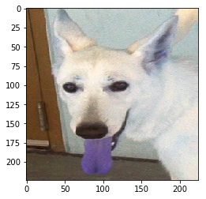

```python
# make prediction
plt.imshow(image.array_to_img(testImg[0]))
model.predict(testImg)
```

### Finetuning of VGG16 with custom to dense layer (simple form) ^

This is a simple recipie for customizing VGG16. We take the full VGG16 model including the Dense layers and just replace the last layer to fit our specific classes.

```python
# Generate a model with all layers (with top)
vgg16 = VGG16(weights='imagenet', include_top=True)

#Add a layer where input is the output of the  second last layer
#x = Dense(8, activation='softmax', name='predictions')(vgg16.layers[-2].output)
x = Dense(1, activation='sigmoid', name='predictions')(vgg16.layers[-2].output)

#Then create the corresponding model
my_model = Model(input=vgg16.input, output=x)
my_model.summary()
```

```
____________________________________________________________________________________________________
Layer (type)                     Output Shape          Param #     Connected to
====================================================================================================
input_40 (InputLayer)            (None, 224, 224, 3)   0
____________________________________________________________________________________________________
block1_conv1 (Convolution2D)     (None, 224, 224, 64)  1792        input_40[0][0]
____________________________________________________________________________________________________
block1_conv2 (Convolution2D)     (None, 224, 224, 64)  36928       block1_conv1[0][0]
____________________________________________________________________________________________________
block1_pool (MaxPooling2D)       (None, 112, 112, 64)  0           block1_conv2[0][0]
____________________________________________________________________________________________________
block2_conv1 (Convolution2D)     (None, 112, 112, 128) 73856       block1_pool[0][0]
____________________________________________________________________________________________________
block2_conv2 (Convolution2D)     (None, 112, 112, 128) 147584      block2_conv1[0][0]
____________________________________________________________________________________________________
block2_pool (MaxPooling2D)       (None, 56, 56, 128)   0           block2_conv2[0][0]
____________________________________________________________________________________________________
block3_conv1 (Convolution2D)     (None, 56, 56, 256)   295168      block2_pool[0][0]
____________________________________________________________________________________________________
block3_conv2 (Convolution2D)     (None, 56, 56, 256)   590080      block3_conv1[0][0]
____________________________________________________________________________________________________
block3_conv3 (Convolution2D)     (None, 56, 56, 256)   590080      block3_conv2[0][0]
____________________________________________________________________________________________________
block3_pool (MaxPooling2D)       (None, 28, 28, 256)   0           block3_conv3[0][0]
____________________________________________________________________________________________________
block4_conv1 (Convolution2D)     (None, 28, 28, 512)   1180160     block3_pool[0][0]
____________________________________________________________________________________________________
block4_conv2 (Convolution2D)     (None, 28, 28, 512)   2359808     block4_conv1[0][0]
____________________________________________________________________________________________________
block4_conv3 (Convolution2D)     (None, 28, 28, 512)   2359808     block4_conv2[0][0]
____________________________________________________________________________________________________
block4_pool (MaxPooling2D)       (None, 14, 14, 512)   0           block4_conv3[0][0]
____________________________________________________________________________________________________
block5_conv1 (Convolution2D)     (None, 14, 14, 512)   2359808     block4_pool[0][0]
____________________________________________________________________________________________________
block5_conv2 (Convolution2D)     (None, 14, 14, 512)   2359808     block5_conv1[0][0]
____________________________________________________________________________________________________
block5_conv3 (Convolution2D)     (None, 14, 14, 512)   2359808     block5_conv2[0][0]
____________________________________________________________________________________________________
block5_pool (MaxPooling2D)       (None, 7, 7, 512)     0           block5_conv3[0][0]
____________________________________________________________________________________________________
flatten (Flatten)                (None, 25088)         0           block5_pool[0][0]
____________________________________________________________________________________________________
fc1 (Dense)                      (None, 4096)          102764544   flatten[0][0]
____________________________________________________________________________________________________
fc2 (Dense)                      (None, 4096)          16781312    fc1[0][0]
____________________________________________________________________________________________________
predictions (Dense)              (None, 1)             4097        fc2[0][0]
====================================================================================================
Total params: 134,264,641
Trainable params: 134,264,641
Non-trainable params: 0
____________________________________________________________________________________________________
```

```python
for i, layer in enumerate(my_model.layers[:-1]):
    log.info("Freeze layer", layer=layer.name)
    layer.trainable = False
```

```
layer='input_40' event='Freeze layer'
layer='block1_conv1' event='Freeze layer'
layer='block1_conv2' event='Freeze layer'
layer='block1_pool' event='Freeze layer'
layer='block2_conv1' event='Freeze layer'
layer='block2_conv2' event='Freeze layer'
layer='block2_pool' event='Freeze layer'
layer='block3_conv1' event='Freeze layer'
layer='block3_conv2' event='Freeze layer'
layer='block3_conv3' event='Freeze layer'
layer='block3_pool' event='Freeze layer'
layer='block4_conv1' event='Freeze layer'
layer='block4_conv2' event='Freeze layer'
layer='block4_conv3' event='Freeze layer'
layer='block4_pool' event='Freeze layer'
layer='block5_conv1' event='Freeze layer'
layer='block5_conv2' event='Freeze layer'
layer='block5_conv3' event='Freeze layer'
layer='block5_pool' event='Freeze layer'
layer='flatten' event='Freeze layer'
layer='fc1' event='Freeze layer'
layer='fc2' event='Freeze layer'
```

```python
# compile the model (should be done *after* setting layers to non-trainable)
my_model.compile(loss='binary_crossentropy',
              optimizer=SGD(lr=1e-4, momentum=0.9),
              metrics=['accuracy'])
```

```python
# the predict_generator method returns the output of a model, given a generator that yields batches of numpy data
my_model.fit_generator(train_generator, 200, nb_epoch=1)
my_model.save('my_model.ft.h5')
```

```
<keras.callbacks.History at 0x3c43fcd30>
```

```
array([[ 0.4732]], dtype=float32)
```

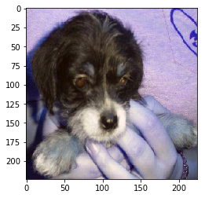

```python
# make prediction
plt.imshow(image.array_to_img(testImg[0]))
my_model.predict(testImg)
```

## Generate Predictions ^

```python
def get_batches(path, gen=image.ImageDataGenerator(), shuffle=True, batch_size=8, class_mode='binary'):
    return gen.flow_from_directory(path,
                                   target_size=(224,224),
                                   class_mode=class_mode,
                                   shuffle=shuffle,
                                   batch_size=batch_size)

test_batches = get_batches('sample/test', shuffle=False, batch_size=batch_size, class_mode='binary')
```

```
Found 20 images belonging to 1 classes.
```

```python
# get predictions
preds = model.predict_generator(test_batches, test_batches.nb_sample)
```

```
(1.0, 'unknown/10319.jpg')
(1.0, 'unknown/11032.jpg')
(1.0, 'unknown/11496.jpg')
(1.0, 'unknown/155.jpg')
(7.4780208e-27, 'unknown/1858.jpg')
```

```
[None, None, None, None, None]
```

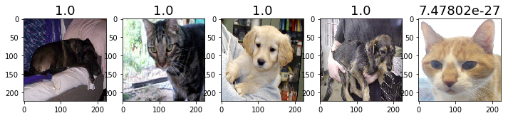

```python
# print 5 predictions
start = 0
pics = []

[print(p) for p in zip(preds[start:start+5, 0], filenames[start:start+5])]

for path in filenames[start:start+5]:
    pics.append(image.load_img('sample/test/'+path, target_size=(224, 224)))

plots(pics, titles=preds[start:start+5, 0])
```

```python
#Save our test results arrays so we can use them again later
save_array(results_path + 'test_preds.dat', preds)
save_array(results_path + 'filenames.dat', filenames)
```

## Validate Predictions ^

Keras' *fit()* function conveniently shows us the value of the loss function, and the accuracy, after every epoch ("*epoch*" refers to one full run through all training examples). The most important metrics for us to look at are for the validation set, since we want to check for over-fitting.

- **Tip**: with our first model we should try to overfit before we start worrying about how to reduce over-fitting - there's no point even thinking about regularization, data augmentation, etc if you're still under-fitting! (We'll be looking at these techniques shortly).

As well as looking at the overall metrics, it's also a good idea to look at examples of each of:

1. A few correct labels at random
2. A few incorrect labels at random
3. The most correct labels of each class (ie those with highest probability that are correct)
4. The most incorrect labels of each class (ie those with highest probability that are incorrect)
5. The most uncertain labels (ie those with probability closest to 0.5).

Let's see what we can learn from these examples. (In general, this is a particularly useful technique for debugging problems in the model. However, since this model is so simple, there may not be too much to learn at this stage.)

Calculate predictions on validation set, so we can find correct and incorrect examples:

```python
vgg.model.load_weights(results_path+latest_weights_filename)
```

```python
val_batches, probs = vgg.test(valid_path, batch_size = batch_size)
```

```python
filenames = val_batches.filenames
expected_labels = val_batches.classes #0 or 1

#Round our predictions to 0/1 to generate labels
our_predictions = probs[:,0]
our_labels = np.round(1-our_predictions)
```

```python
from keras.preprocessing import image

#Helper function to plot images by index in the validation set
#Plots is a helper function in utils.py
def plots_idx(idx, titles=None):
    plots([image.load_img(valid_path + filenames[i]) for i in idx], titles=titles)

#Number of images to view for each visualization task
n_view = 4
```

```python
#1. A few correct labels at random
correct = np.where(our_labels==expected_labels)[0]
print "Found %d correct labels" % len(correct)
idx = permutation(correct)[:n_view]
plots_idx(idx, our_predictions[idx])
```

```python
#2. A few incorrect labels at random
incorrect = np.where(our_labels!=expected_labels)[0]
print "Found %d incorrect labels" % len(incorrect)
idx = permutation(incorrect)[:n_view]
plots_idx(idx, our_predictions[idx])
```

```python
#3a. The images we most confident were cats, and are actually cats
correct_cats = np.where((our_labels==0) & (our_labels==expected_labels))[0]
print "Found %d confident correct cats labels" % len(correct_cats)
most_correct_cats = np.argsort(our_predictions[correct_cats])[::-1][:n_view]
plots_idx(correct_cats[most_correct_cats], our_predictions[correct_cats][most_correct_cats])
```

```python
#3b. The images we most confident were dogs, and are actually dogs
correct_dogs = np.where((our_labels==1) & (our_labels==expected_labels))[0]
print "Found %d confident correct dogs labels" % len(correct_dogs)
most_correct_dogs = np.argsort(our_predictions[correct_dogs])[:n_view]
plots_idx(correct_dogs[most_correct_dogs], our_predictions[correct_dogs][most_correct_dogs])
```

```python
#4a. The images we were most confident were cats, but are actually dogs
incorrect_cats = np.where((our_labels==0) & (our_labels!=expected_labels))[0]
print "Found %d incorrect cats" % len(incorrect_cats)
if len(incorrect_cats):
    most_incorrect_cats = np.argsort(our_predictions[incorrect_cats])[::-1][:n_view]
    plots_idx(incorrect_cats[most_incorrect_cats], our_predictions[incorrect_cats][most_incorrect_cats])
```

```python
#4b. The images we were most confident were dogs, but are actually cats
incorrect_dogs = np.where((our_labels==1) & (our_labels!=expected_labels))[0]
print "Found %d incorrect dogs" % len(incorrect_dogs)
if len(incorrect_dogs):
    most_incorrect_dogs = np.argsort(our_predictions[incorrect_dogs])[:n_view]
    plots_idx(incorrect_dogs[most_incorrect_dogs], our_predictions[incorrect_dogs][most_incorrect_dogs])
```

```python
#5. The most uncertain labels (ie those with probability closest to 0.5).
most_uncertain = np.argsort(np.abs(our_predictions-0.5))
plots_idx(most_uncertain[:n_view], our_predictions[most_uncertain])
```

Perhaps the most common way to analyze the result of a classification model is to use a [confusion matrix](http://www.dataschool.io/simple-guide-to-confusion-matrix-terminology/). Scikit-learn has a convenient function we can use for this purpose:

```python
from sklearn.metrics import confusion_matrix
cm = confusion_matrix(expected_labels, our_labels)
```

We can just print out the confusion matrix, or we can show a graphical view (which is mainly useful for dependents with a larger number of categories).

```python
plot_confusion_matrix(cm, val_batches.class_indices)
```

## Submit Predictions to Kaggle! ^

Here's the format Kaggle requires for new submissions:

```
imageId,isDog
1242, .3984
3947, .1000
4539, .9082
2345, .0000
```

Kaggle wants the imageId followed by the probability of the image being a dog. Kaggle uses a metric called [Log Loss](http://wiki.fast.ai/index.php/Log_Loss) to evaluate your submission.

```python
#Load our test predictions from file
preds = load_array(results_path + 'test_preds.dat')
filenames = load_array(results_path + 'filenames.dat')
```

```python
#Grab the dog prediction column
isdog = preds[:,1]
print "Raw Predictions: " + str(isdog[:5])
print "Mid Predictions: " + str(isdog[(isdog < .6) & (isdog > .4)])
print "Edge Predictions: " + str(isdog[(isdog == 1) | (isdog == 0)])
```

[Log Loss](http://wiki.fast.ai/index.php/Log_Loss) doesn't support probability values of 0 or 1--they are undefined (and we have many). Fortunately, Kaggle helps us by offsetting our 0s and 1s by a very small value. So if we upload our submission now we will have lots of .99999999 and .000000001 values. This seems good, right?

```python
#Visualize Log Loss when True value = 1
#y-axis is log loss, x-axis is probabilty that label = 1
#As you can see Log Loss increases rapidly as we approach 0
#But increases slowly as our predicted probability gets closer to 1
import matplotlib.pyplot as plt
import numpy as np
from sklearn.metrics import log_loss

x = [i*.0001 for i in range(1,10000)]
y = [log_loss([1],[[i*.0001,1-(i*.0001)]],eps=1e-15) for i in range(1,10000,1)]

plt.plot(x, y)
plt.axis([-.05, 1.1, -.8, 10])
plt.title("Log Loss when true label = 1")
plt.xlabel("predicted probability")
plt.ylabel("log loss")

plt.show()
```

```python
#So to play it safe, we use a sneaky trick to round down our edge predictions
#Swap all ones with .95 and all zeros with .05
isdog = isdog.clip(min=0.05, max=0.95)
```

```python
#Extract imageIds from the filenames in our test/unknown directory
filenames = batches.filenames
ids = np.array([int(f[8:f.find('.')]) for f in filenames])
```

Here we join the two columns into an array of [imageId, isDog]

```python
subm = np.stack([ids,isdog], axis=1)
subm[:5]
```

```python
%cd $DATA_HOME_DIR
submission_file_name = 'submission1.csv'
np.savetxt(submission_file_name, subm, fmt='%d,%.5f', header='id,label', comments='')
```

```python
from IPython.display import FileLink
%cd $LESSON_HOME_DIR
FileLink('data/redux/'+submission_file_name)
```

You can download this file and submit on the Kaggle website or use the Kaggle command line tool's "submit" method.

## Under/Overfitting ^

We do not necessarily need to rely on dropout or other regularization approaches to reduce overfitting. There are other techniques we should try first, since regularlization, by definition, biases our model towards simplicity - which we only want to do if we know that's necessary. This is the order that we recommend using for reducing overfitting (more details about each in a moment):

1. Add more data
2. Use data augmentation
3. Use architectures that generalize well
4. Add regularization
5. Reduce architecture complexity.

We'll assume that you've already collected as much data as you can, so step (1) isn't relevant (this is true for most Kaggle competitions, for instance). So the next step (2) is data augmentation. This refers to creating additional synthetic data, based on reasonable modifications of your input data. For images, this is likely to involve one or more of: flipping, rotation, zooming, cropping, panning, minor color changes.

Which types of augmentation are appropriate depends on your data. For regular photos, for instance, you'll want to use horizontal flipping, but not vertical flipping (since an upside down car is much less common than a car the right way up, for instance!)

We recommend **always** using at least some light data augmentation, unless you have so much data that your model will never see the same input twice.